# Beer_Analysis_EDA

Kevin Thompson and Stuart Miller

6/16/2019

# Setup

### Load Libraries

```r
library(tidyverse)
library(ggplot2)
library(reshape2)
```

### Load Data

Be sure to run `make` in `./analysis/data` first.

```r
load('./data/.RData')
```

# EDA

The file contains base EDA preformed. This will be followed with a final analysis file.

## Method

1. Start with preliminaries - structure of data.
2. Use questions of assignment as EDA guide and expand where interested.

## Structure of Data

```r
# just use `str`
str(beer_data)
```

```
## Classes 'rowwise_df', 'tbl_df', 'tbl' and 'data.frame':  2410 obs. of  8 variables:
##  $ Beer_name : chr  "Pub Beer" "Devil's Cup" "Rise of the Phoenix" "Sinister" ...
##  $ Beer_ID   : chr  "1436" "2265" "2264" "2263" ...
##  $ ABV       : num  0.05 0.066 0.071 0.09 0.075 0.077 0.045 0.065 0.055 0.086 ...
##  $ IBU       : num  NA NA NA NA NA NA NA NA NA NA ...
##  $ Brewery_id: chr  "409" "178" "178" "178" ...
##  $ Style     : chr  "American Pale Lager" "American Pale Ale (APA)" "American IPA" "American Double / Imperial IPA" ...
##  $ Ounces    : chr  "12" "12" "12" "12" ...
##  $ ShortStyle: Factor w/ 46 levels "Lager","Ale",..: 1 2 3 3 3 4 2 5 2 3 ...
```

```r
str(brewery_data)
```

```
## Classes 'tbl_df', 'tbl' and 'data.frame':    558 obs. of  4 variables:
##  $ Brewery_id  : chr  "1" "2" "3" "4" ...
##  $ Brewery_name: chr  "NorthGate Brewing" "Against the Grain Brewery" "Jack's Abby Craft Lagers" "Mike Hess Brewing Company" ...
##  $ City        : chr  "Minneapolis" "Louisville" "Framingham" "San Diego" ...
##  $ State       : chr  "MN" "KY" "MA" "CA" ...
##  - attr(*, "spec")=List of 2
##   ..$ cols   :List of 4
##   .. ..$ Brew_ID: list()
##   .. .. ..- attr(*, "class")= chr  "collector_character" "collector"
##   .. ..$ Name   : list()
##   .. .. ..- attr(*, "class")= chr  "collector_character" "collector"
##   .. ..$ City   : list()
##   .. .. ..- attr(*, "class")= chr  "collector_character" "collector"
##   .. ..$ State  : list()
##   .. .. ..- attr(*, "class")= chr  "collector_character" "collector"
##   ..$ default: list()
##   .. ..- attr(*, "class")= chr  "collector_guess" "collector"
##   ..- attr(*, "class")= chr "col_spec"
```

Most columns are factors or characters. `ABV` and `IBU` are the only numeric columns.

## EDA

### Look at breweries and beers per state and city

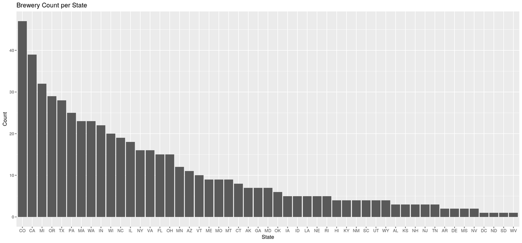

```r
# get counts of breweries per state
brewerysPerState <- brewery_data %>%
  group_by(State) %>%
  summarise(Brewery_name = length(State))
# order the result
brewerysPerState <- brewerysPerState[order(-brewerysPerState$Brewery_name), ]
# better name for column
names(brewerysPerState)[2] <- 'BreweryCount'
# plot count vs state (bar)
ggplot(data=brewerysPerState, aes(x = reorder(State, -BreweryCount), y = BreweryCount)) +
  geom_bar(stat = 'identity') +
  xlab('State') +
  ylab('Count') +
  ggtitle('Brewery Count per State')
```

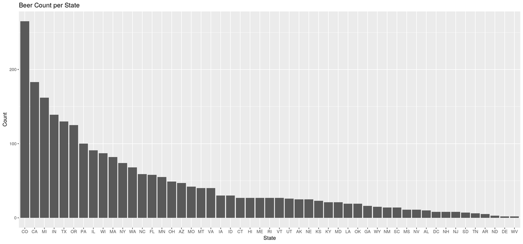

```r
# get counts of breweries per state
beersPerState <- merged_data %>%
  group_by(State) %>%
  summarise(Beer_ID = length(State))
# order the result
beersPerState <- beersPerState[order(-beersPerState$Beer_ID), ]
# better name for column
names(beersPerState)[2] <- 'BreweryCount'
# plot count vs state (bar)
ggplot(data=beersPerState, aes(x = reorder(State, -BreweryCount), y = BreweryCount)) +
  geom_bar(stat = 'identity') +
  xlab('State') +
  ylab('Count') +
  ggtitle('Beer Count per State')
```

Look at number of breweries per city. Subset on top 20 as there are a large number of cities in the data set.

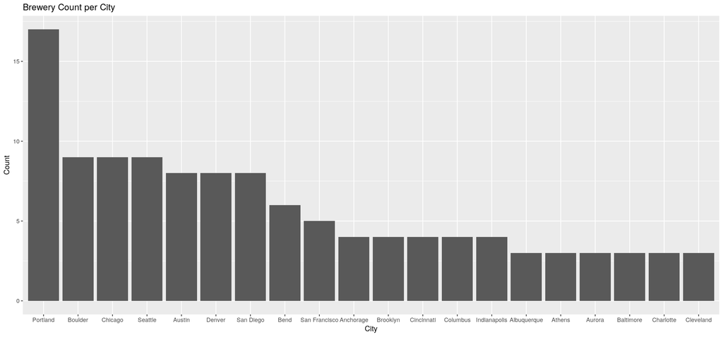

```r
# get counts of breweries per state
brewerysPerCity <- brewery_data %>%
  group_by(City) %>%
  summarise(Brewery_name = length(City))
# order the result
brewerysPerCity <- brewerysPerCity[order(-brewerysPerCity$Brewery_name), ]
# better name for column
names(brewerysPerCity)[2] <- 'BreweryCount'
# plot count vs state (bar)
ggplot(data=head(brewerysPerCity,20), aes(x = reorder(City, -BreweryCount), y = BreweryCount)) +
  geom_bar(stat = 'identity') +
  xlab('City') +
  ylab('Count') +
  ggtitle('Brewery Count per City')
```

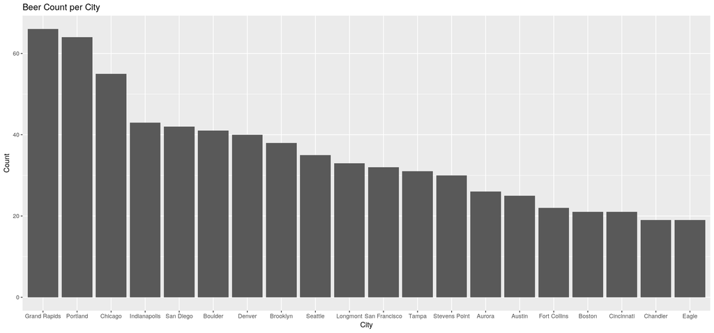

```r
# get counts of breweries per state
beersPerCity <- merged_data %>%
  group_by(City) %>%
  summarise(Beer_ID = length(City))
# order the result
beersPerCity <- beersPerCity[order(-beersPerCity$Beer_ID), ]
# better name for column
names(beersPerCity)[2] <- 'BeerCount'
# plot count vs state (bar)
ggplot(data=head(beersPerCity,20), aes(x = reorder(City, -BeerCount), y = BeerCount)) +
  geom_bar(stat = 'identity') +
  xlab('City') +
  ylab('Count') +
  ggtitle('Beer Count per City')
```

Interestingly, the city with the highest number of breweries and highest number of unique beers do not match. For example, Grand Rapids has the highest number of unique beers, but is not in the top 20 cities of brewery count. This may have to do with how big name ‘chain’ breweries are distributed over cities and state.

### Verify merged data looks correct

Since data was merged in `make` step, just check to make sure it looks right.

```r
head(merged_data)
```

```
##   Brewery_id      Brewery_name        City State     Beer_name Beer_ID
## 1          1 NorthGate Brewing Minneapolis    MN       Pumpion    2689
## 2          1 NorthGate Brewing Minneapolis    MN    Stronghold    2688
## 3          1 NorthGate Brewing Minneapolis    MN   Parapet ESB    2687
## 4          1 NorthGate Brewing Minneapolis    MN  Get Together    2692
## 5          1 NorthGate Brewing Minneapolis    MN Maggie's Leap    2691
## 6          1 NorthGate Brewing Minneapolis    MN    Wall's End    2690
##     ABV IBU                               Style Ounces ShortStyle
## 1 0.060  38                         Pumpkin Ale     16        Ale
## 2 0.060  25                     American Porter     16     Porter
## 3 0.056  47 Extra Special / Strong Bitter (ESB)     16     Bitter
## 4 0.045  50                        American IPA     16        IPA
## 5 0.049  26                  Milk / Sweet Stout     16      Stout
## 6 0.048  19                   English Brown Ale     16        Ale
```

```r
tail(merged_data)
```

```
##      Brewery_id           Brewery_name      City State
## 2405         98 Tröegs Brewing Company   Hershey    PA
## 2406         98 Tröegs Brewing Company   Hershey    PA
## 2407         99        Mission Brewery San Diego    CA
## 2408         99        Mission Brewery San Diego    CA
## 2409         99        Mission Brewery San Diego    CA
## 2410         99        Mission Brewery San Diego    CA
##                           Beer_name Beer_ID   ABV IBU
## 2405                  Perpetual IPA    1509 0.075  85
## 2406         Troegenator Doublebock    1510 0.082  25
## 2407                    Cortez Gold    2442 0.050  NA
## 2408                    Mission IPA    2441 0.068  66
## 2409 El Conquistador Extra Pale Ale    1460 0.048  44
## 2410         Shipwrecked Double IPA    1459 0.092  75
##                               Style Ounces ShortStyle
## 2405                   American IPA     12        IPA
## 2406                     Doppelbock     16 Doppelbock
## 2407               Belgian Pale Ale     32        Ale
## 2408                   American IPA     32        IPA
## 2409        American Pale Ale (APA)     32        Ale
## 2410 American Double / Imperial IPA     32        IPA
```

Data appear to be correcly merged based on head and tail of `data.frame()`. However, this would only catch gross errors in merge.

### Look at `NA`s in columns of merged data

```r
nas.in.merged.data <- colSums(is.na(merged_data))
nas.in.merged.data
```

```
##   Brewery_id Brewery_name         City        State    Beer_name
##            0            0            0            0            0
##      Beer_ID          ABV          IBU        Style       Ounces
##            0           62         1005            5            0
##   ShortStyle
##            5
```

Look at missing data as a percent of the total for `IBU` and `ABV`.

```r
(nas.in.merged.data/length(merged_data$IBU)*100)[c(7,8)]
```

```
##       ABV       IBU
##  2.572614 41.701245
```

| Column Name | Number of Missing Values | Percent of Values Missing |
| --- | --- | --- |
| IBU | 1005 | 41.70% |
| ABV | 62 | 2.57% |

These missing data summaries suggests the question: ‘how are these missing values distributed over the factors?’ Look at missing IBU values per state.

```r
# function to aggregate missing values in column by factor
nacheck <- function(var, factor)
    aggregate(var, list(factor), function(x) sum(is.na(x)))
```

```r
# count beers per state because IBU and ABV are
# per beer i.e. per beer ID
BeerCountPerState <- merged_data %>%
  group_by(State) %>%
  summarise(Beer_ID = length(State))
# pick some better names
names(BeerCountPerState) <- c('State','CountOfBeerID')

# get missing IBU values by state
MissingIBUPerState <- nacheck(merged_data$IBU, merged_data$State)
# pick some better names
names(MissingIBUPerState) <- c('State','MissingIBUCount')

# calculate percentage of missing IBU values per state
MissingIBUPerState$PercentIBUMissing <-
  MissingIBUPerState$MissingIBUCount/BeerCountPerState$CountOfBeerID

# get missing ABV values by state
MissingABVPerState <- nacheck(merged_data$ABV, merged_data$State)
# pick some better names
names(MissingABVPerState) <- c('State','MissingABVCount')

# calculate percentage of missing ABV values per state
MissingABVPerState$PercentABVMissing <-
  MissingABVPerState$MissingABVCount/BeerCountPerState$CountOfBeerID
```

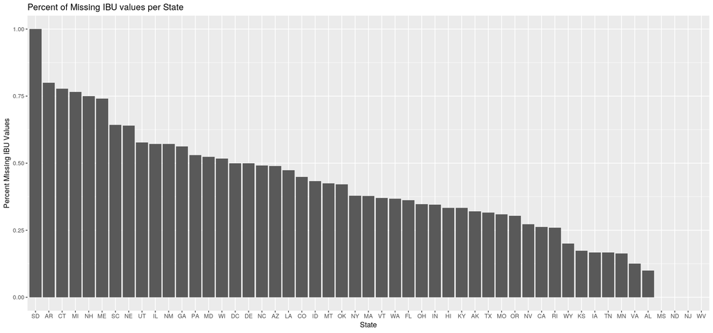

```r
# plot % missing IBU values vs state (bar)
ggplot(data=MissingIBUPerState, aes(x = reorder(State, -PercentIBUMissing), y = PercentIBUMissing)) +
  geom_bar(stat = 'identity') +
  xlab('State') +
  ylab('Percent Missing IBU Values') +
  ggtitle('Percent of Missing IBU values per State')
```

A large number of states are heavily affected by the missing values of IBU.

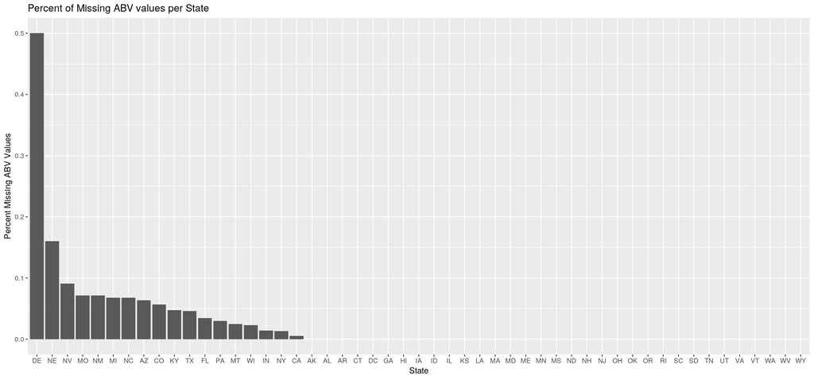

```r
# plot % missing ABV values vs state (bar)
ggplot(data=MissingABVPerState, aes(x = reorder(State, -PercentABVMissing), y = PercentABVMissing)) +
  geom_bar(stat = 'identity') +
  xlab('State') +
  ylab('Percent Missing ABV Values') +
  ggtitle('Percent of Missing ABV values per State')
```

A small number of states are heavily affected by the missing values of `ABV`, primarily, Delaware, Nebraska, and Nevada.

### Cursory Look at `IBU` and `ABV`

- Alcohol content is labeled `ABV`.
- International bitterness unit is labled `IBU`.

Look at histograms for `IBU` and `ABV`. `NA`s will be removed for histograms.

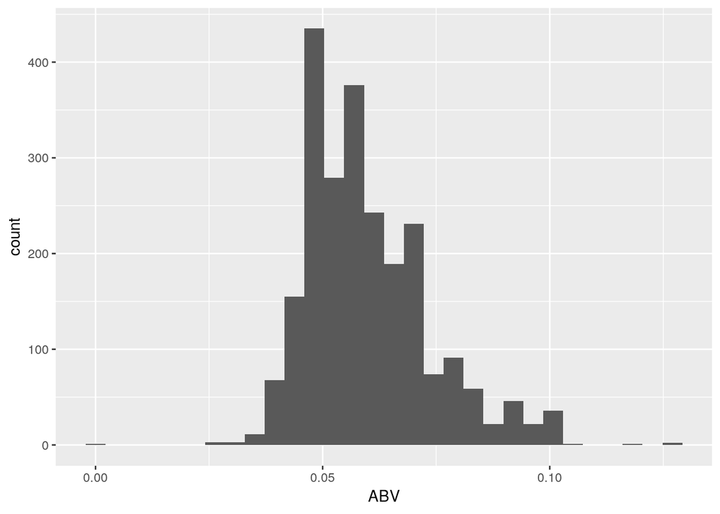

```r
# plot distributions of `ABV` and `IBU`
ggplot(data = merged_data, aes(x = ABV)) + geom_histogram(bins = 30)
```

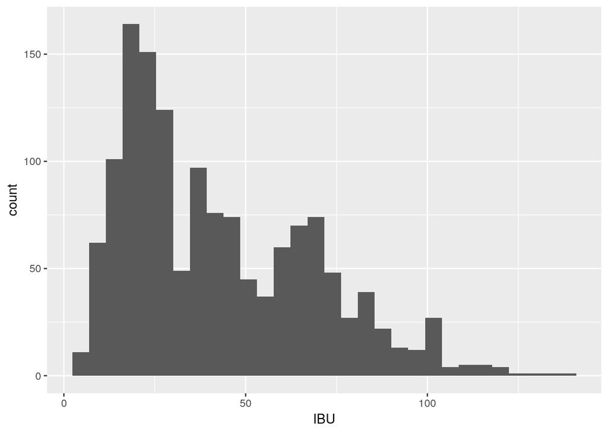

```r
ggplot(data = merged_data, aes(x = IBU)) + geom_histogram(bins = 30)
```

### **Statistical Summary Calculations for `IBU` and `ABV`**

Calcaculate summary statistics for `IBU` and `ABV`. It will be necessary to remove rows with `NA` to make summary calculations.

```r
# calc summary stats for IBU
IBUByState <- merged_data %>%
  filter(!is.na(IBU)) %>%
  group_by(State) %>%
  summarise(Mean=mean(IBU), Max=max(IBU), Min=min(IBU), Median=median(IBU), Std=sd(IBU))
```

```r
# calc summary stats for ABV
ABVByState <- merged_data %>%
  filter(!is.na(ABV)) %>%
  group_by(State) %>%
  summarise(Mean=mean(ABV), Max=max(ABV), Min=min(ABV), Median=median(ABV), Std=sd(ABV))
```

Look at summary stats side-by-side.

```r
# melt ByState data.frames to view stats side-by-side
IBUByState.long<-melt(IBUByState, id.vars = 'State')
ABVByState.long<-melt(ABVByState, id.vars = 'State')
```

#### Plots of `IBU` Statistics Per State

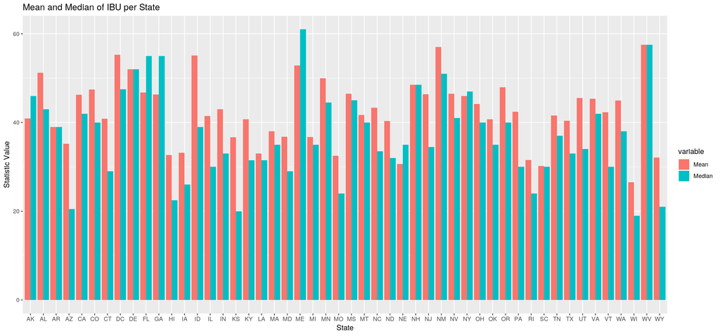

```r
ggplot(IBUByState.long[IBUByState.long$variable %in% c('Mean','Median'), ],
       aes(x=State, y=value, fill = variable)) +
    geom_bar(stat='identity', position='dodge') +
  ggtitle('Mean and Median of IBU per State') +
  xlab('State') + ylab('Statistic Value')
```

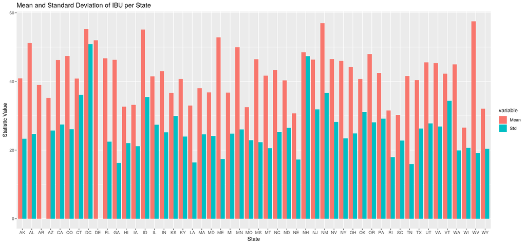

```r
ggplot(IBUByState.long[IBUByState.long$variable %in% c('Mean','Std'), ],
       aes(x=State, y=value, fill = variable)) +
    geom_bar(stat='identity', position='dodge') +
  ggtitle('Mean and Standard Deviation of IBU per State') +
  xlab('State') + ylab('Statistic Value')
```

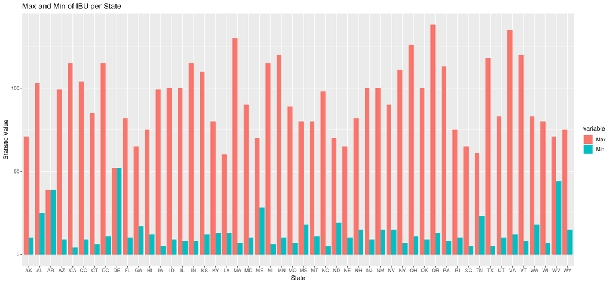

```r
ggplot(IBUByState.long[IBUByState.long$variable %in% c('Max','Min'), ],
       aes(x=State, y=value, fill = variable)) +
    geom_bar(stat='identity', position='dodge') +
  ggtitle('Max and Min of IBU per State') +
  xlab('State') + ylab('Statistic Value')
```

#### Plots of `ABV` Statistics Per State

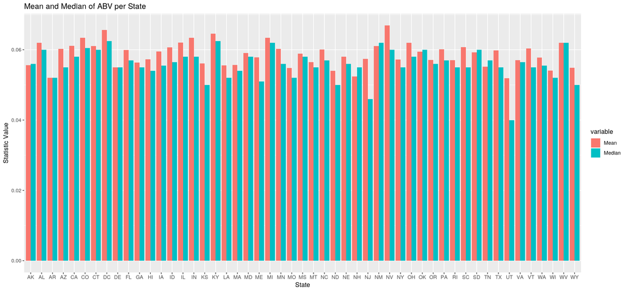

```r
ggplot(ABVByState.long[ABVByState.long$variable %in% c('Mean','Median'), ],
       aes(x=State, y=value, fill = variable)) +
    geom_bar(stat='identity', position='dodge') +
  ggtitle('Mean and Median of ABV per State') +
  xlab('State') + ylab('Statistic Value')
```

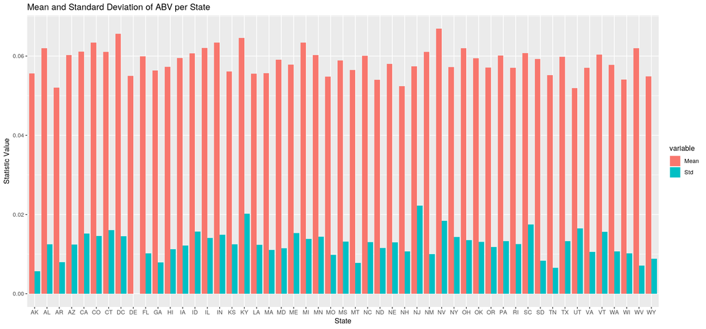

```r
ggplot(ABVByState.long[ABVByState.long$variable %in% c('Mean','Std'), ],
       aes(x=State, y=value, fill = variable)) +
    geom_bar(stat='identity', position='dodge') +
  ggtitle('Mean and Standard Deviation of ABV per State') +
  xlab('State') + ylab('Statistic Value')
```

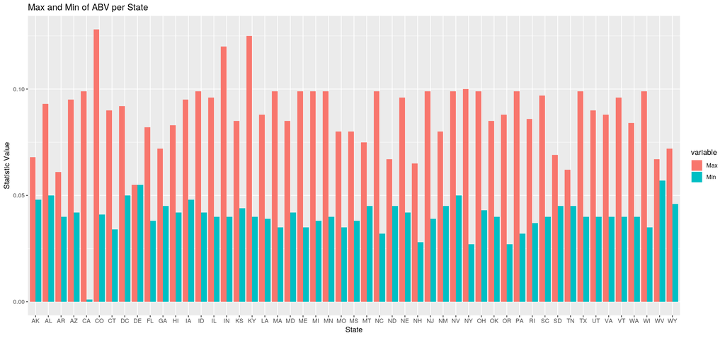

```r
ggplot(ABVByState.long[ABVByState.long$variable %in% c('Max','Min'), ],
       aes(x=State, y=value, fill = variable)) +
    geom_bar(stat='identity', position='dodge') +
  ggtitle('Max and Min of ABV per State') +
  xlab('State') + ylab('Statistic Value')
```